# Analyzing Stanley Cup Champions 1927-2019

#### This notebook takes Stanley Cup Finals data scraped from Wikipedia) using [VBA](https://github.com/cwils021/Stanley-Cup-Champs-1927-2019/blob/master/StanleyCupChamp1927_2019_VBAScript.md) and cleans it to an acceptable format for basic exploratory analysis

## Step 1: Download the Data

To begin, users can download the original data from this [Repo](https://github.com/cwils021/Stanley-Cup-Champs-1927-2019/blob/master/_data/SCC1927-2019.csv), or can try scraping the data themselves from Wikipedia using the above [VBA](https://github.com/cwils021/Stanley-Cup-Champs-1927-2019/blob/master/StanleyCupChamp1927_2019_VBAScript.md) script

## Step 2: Import Data and Packages

```python
%matplotlib inline
import pandas as pd
from collections import Counter
import numpy as np
import matplotlib.pyplot as plt
data = pd.read_csv("C:/Users/chris/Documents/GitHub Repos/Stanley-Cup-Champs-1927-2019/_data/SCC1927-2019.csv",
                   header=0)
data = data.set_index('Year')
data.head()
```

| Year | Winning team | Coach | Games | Losing team | Coach.1 | Winning goal |
| --- | --- | --- | --- | --- | --- | --- |
| 1927 | Ottawa Senators (C) (5, 4–1) | Dave Gill | 2–0–2 | Boston Bruins (A) (1, 0–1) | Art Ross | Cy Denneny (7:30, second)\n |
| 1928 | New York Rangers (A) (1, 1–0) | Lester Patrick-playing | 3–2 | Montreal Maroons (C) (2, 1–1) | Eddie Gerard | Frank Boucher (3:35, third)\n |
| 1929 | Boston Bruins (A) (2, 1–1) | Cy Denneny-playing | 2–0 | New York Rangers (A) (2, 1–1) | Lester Patrick | Bill Carson (18:02, third)\n |
| 1930 | Montreal Canadiens (C) (6, 3–2) | Cecil Hart | 2–0 | Boston Bruins (A) (3, 1–2) | Art Ross | Howie Morenz (1:00, second)\n |
| 1931 | Montreal Canadiens (C) (7, 4–2) | Cecil Hart | 3–2 | Chicago Black Hawks (A) (1, 0–1) | Dick Irvin | Johnny Gagnon (9:59, second)\n |

Now that the data has successfully been loaded, we set the index to year. From printing the data it can also be seen that there is quite a bit of cleaning to do before we can properly analyze it. These data cleaning objectives include:

- The year 2005 needs to be dropped due to the 04/05 NHL Season Lockout where no playoffs occurred
- column names - they contain spaces and are not all unique (coach, coach.1)
- winning and losing team columns actually contain the team name, conference, total apperances to the finals to date, and record to date
- the winning goal column similar to the teams columns contains multiple pieces of information (goal scorer, time of game winning goal, period of game winning goal)

## Step 3: Drop 2005 and Clean Column Names

```python
data = data.drop(2005,axis=0)
data = data.rename(columns={"Winning team": "team_win",
                            "Coach": "coach_win",
                            "Losing team": "team_lose",
                            "Coach.1": "coach_lose",
                            "Winning goal\n": "win_gs"
                            })
data.head()
```

| Year | team_win | coach_win | Games | team_lose | coach_lose | win_gs |
| --- | --- | --- | --- | --- | --- | --- |
| 1927 | Ottawa Senators (C) (5, 4–1) | Dave Gill | 2–0–2 | Boston Bruins (A) (1, 0–1) | Art Ross | Cy Denneny (7:30, second)\n |
| 1928 | New York Rangers (A) (1, 1–0) | Lester Patrick-playing | 3–2 | Montreal Maroons (C) (2, 1–1) | Eddie Gerard | Frank Boucher (3:35, third)\n |
| 1929 | Boston Bruins (A) (2, 1–1) | Cy Denneny-playing | 2–0 | New York Rangers (A) (2, 1–1) | Lester Patrick | Bill Carson (18:02, third)\n |
| 1930 | Montreal Canadiens (C) (6, 3–2) | Cecil Hart | 2–0 | Boston Bruins (A) (3, 1–2) | Art Ross | Howie Morenz (1:00, second)\n |
| 1931 | Montreal Canadiens (C) (7, 4–2) | Cecil Hart | 3–2 | Chicago Black Hawks (A) (1, 0–1) | Dick Irvin | Johnny Gagnon (9:59, second)\n |

## Step 4: Clean team_win Column

```python
#split record and appearances from win_team
data[['team_win','DROP','WREC']] = data.team_win.str.rpartition('(')
data = data.drop('DROP', axis=1)
data['team_win'] = data.team_win.str.rstrip()
#data.head() #uncomment this line to view how data changes
```

```python
#create temp df to split conf from win_team
temp = data.team_win.str.rsplit("(",1).to_frame()
temp[['win_team','wcon']] = pd.DataFrame(temp.team_win.values.tolist(),index=temp.index)
temp = temp.drop('team_win',axis=1)
#temp.head() #uncomment this line to view how data changes
```

```python
#add team_Win and wcon to df
data[['team_win','wcon']] = temp[['win_team','wcon']]
data['wcon'] = data.wcon.str.rstrip(')')
data['wcon'] = data.wcon.str.lstrip()
#data.head() #uncomment this line to view how data changes
```

```python
#clean WREC col by splitting apperances to date and record to date
data[['wt_app2d','DROP','wt_rec2d']] = data.WREC.str.partition(',')
data = data.drop(['WREC','DROP'],axis=1)
data['wt_rec2d'] = data.wt_rec2d.str.rstrip(')')
data.head()
```

| Year | team_win | coach_win | Games | team_lose | coach_lose | win_gs | wcon | wt_app2d | wt_rec2d |
| --- | --- | --- | --- | --- | --- | --- | --- | --- | --- |
| 1927 | Ottawa Senators | Dave Gill | 2–0–2 | Boston Bruins (A) (1, 0–1) | Art Ross | Cy Denneny (7:30, second)\n | C | 5 | 4–1 |
| 1928 | New York Rangers | Lester Patrick-playing | 3–2 | Montreal Maroons (C) (2, 1–1) | Eddie Gerard | Frank Boucher (3:35, third)\n | A | 1 | 1–0 |
| 1929 | Boston Bruins | Cy Denneny-playing | 2–0 | New York Rangers (A) (2, 1–1) | Lester Patrick | Bill Carson (18:02, third)\n | A | 2 | 1–1 |
| 1930 | Montreal Canadiens | Cecil Hart | 2–0 | Boston Bruins (A) (3, 1–2) | Art Ross | Howie Morenz (1:00, second)\n | C | 6 | 3–2 |
| 1931 | Montreal Canadiens | Cecil Hart | 3–2 | Chicago Black Hawks (A) (1, 0–1) | Dick Irvin | Johnny Gagnon (9:59, second)\n | C | 7 | 4–2 |

From the above we can see that the team_win column now only contains the winning team name, and we have created 3 new columns:

- wcon - Conference of winning team
- wt_app2d - Stanley Cup Finals appearances to date of winning team
- wt_rec2d - Stanley Cup Finals record to date of winning team

We can now repeat these steps for the team_lose column.

## Step 5: Clean team_lose Column

```python
#split record and appearances from lose_team
data[['team_lose','DROP','LREC']] = data.team_lose.str.rpartition('(')
data = data.drop('DROP', axis=1)
data['team_lose'] = data.team_lose.str.rstrip()
#data.head() #uncomment this line to view how data changes
```

```python
#create temp df to split conf from lose_team
temp = data.team_lose.str.rsplit("(",1).to_frame()
temp[['lose_team','lcon']] = pd.DataFrame(temp.team_lose.values.tolist(),index=temp.index)
temp = temp.drop('team_lose',axis=1)
#temp.head() #uncomment this line to view how data changes
```

```python
#add team_lose and lcon to df
data[['team_lose','lcon']] = temp[['lose_team','lcon']]
data['lcon'] = data.lcon.str.rstrip(')')
data['lcon'] = data.lcon.str.lstrip()
#data.head() #uncomment this line to view how data changes
```

```python
#clean LREC col by splitting apperances to date and record to date
data[['lt_app2d','DROP','lt_rec2d']] = data.LREC.str.partition(',')
data = data.drop(['LREC','DROP'],axis=1)
data['lt_rec2d'] = data.lt_rec2d.str.rstrip(')')
data.head()
```

| Year | team_win | coach_win | Games | team_lose | coach_lose | win_gs | wcon | wt_app2d | wt_rec2d | lcon | lt_app2d | lt_rec2d |
| --- | --- | --- | --- | --- | --- | --- | --- | --- | --- | --- | --- | --- |
| 1927 | Ottawa Senators | Dave Gill | 2–0–2 | Boston Bruins | Art Ross | Cy Denneny (7:30, second)\n | C | 5 | 4–1 | A | 1 | 0–1 |
| 1928 | New York Rangers | Lester Patrick-playing | 3–2 | Montreal Maroons | Eddie Gerard | Frank Boucher (3:35, third)\n | A | 1 | 1–0 | C | 2 | 1–1 |
| 1929 | Boston Bruins | Cy Denneny-playing | 2–0 | New York Rangers | Lester Patrick | Bill Carson (18:02, third)\n | A | 2 | 1–1 | A | 2 | 1–1 |
| 1930 | Montreal Canadiens | Cecil Hart | 2–0 | Boston Bruins | Art Ross | Howie Morenz (1:00, second)\n | C | 6 | 3–2 | A | 3 | 1–2 |
| 1931 | Montreal Canadiens | Cecil Hart | 3–2 | Chicago Black Hawks | Dick Irvin | Johnny Gagnon (9:59, second)\n | C | 7 | 4–2 | A | 1 | 0–1 |

Now that both the team columns are cleaned we can move on to cleaning the win_gs column using similar steps as above.

## Step 6: Clean win_gs Column

```python
#clean winning goal scorer col
data['win_gs'] = data.win_gs.str.rstrip()
data[['win_gs','DROP','goal_time']] = data.win_gs.str.partition('(')
data = data.drop('DROP',axis=1)
data[['goal_time','DROP','period']] = data.goal_time.str.partition(', ')
data = data.drop('DROP',axis=1)
data['period'] = data.period.str.rstrip(')')
data['win_gs'] = data.win_gs.str.strip()
data.head()
```

| Year | team_win | coach_win | Games | team_lose | coach_lose | win_gs | wcon | wt_app2d | wt_rec2d | lcon | lt_app2d | lt_rec2d | goal_time | period |
| --- | --- | --- | --- | --- | --- | --- | --- | --- | --- | --- | --- | --- | --- | --- |
| 1927 | Ottawa Senators | Dave Gill | 2–0–2 | Boston Bruins | Art Ross | Cy Denneny | C | 5 | 4–1 | A | 1 | 0–1 | 7:30 | second |
| 1928 | New York Rangers | Lester Patrick-playing | 3–2 | Montreal Maroons | Eddie Gerard | Frank Boucher | A | 1 | 1–0 | C | 2 | 1–1 | 3:35 | third |
| 1929 | Boston Bruins | Cy Denneny-playing | 2–0 | New York Rangers | Lester Patrick | Bill Carson | A | 2 | 1–1 | A | 2 | 1–1 | 18:02 | third |
| 1930 | Montreal Canadiens | Cecil Hart | 2–0 | Boston Bruins | Art Ross | Howie Morenz | C | 6 | 3–2 | A | 3 | 1–2 | 1:00 | second |
| 1931 | Montreal Canadiens | Cecil Hart | 3–2 | Chicago Black Hawks | Dick Irvin | Johnny Gagnon | C | 7 | 4–2 | A | 1 | 0–1 | 9:59 | second |

Now that the win_gs column is clean, it looks as if we are ready to start our exploratory data analysis, first however we must check the quality of our data cleaning.

## Step 7: Quality Check

```python
data
```

| Year | team_win | coach_win | Games | team_lose | coach_lose | win_gs | wcon | wt_app2d | wt_rec2d | lcon | lt_app2d | lt_rec2d | goal_time | period |
| --- | --- | --- | --- | --- | --- | --- | --- | --- | --- | --- | --- | --- | --- | --- |
| 1927 | Ottawa Senators | Dave Gill | 2–0–2 | Boston Bruins | Art Ross | Cy Denneny | C | 5 | 4–1 | A | 1 | 0–1 | 7:30 | second |
| 1928 | New York Rangers | Lester Patrick-playing | 3–2 | Montreal Maroons | Eddie Gerard | Frank Boucher | A | 1 | 1–0 | C | 2 | 1–1 | 3:35 | third |
| 1929 | Boston Bruins | Cy Denneny-playing | 2–0 | New York Rangers | Lester Patrick | Bill Carson | A | 2 | 1–1 | A | 2 | 1–1 | 18:02 | third |
| 1930 | Montreal Canadiens | Cecil Hart | 2–0 | Boston Bruins | Art Ross | Howie Morenz | C | 6 | 3–2 | A | 3 | 1–2 | 1:00 | second |
| 1931 | Montreal Canadiens | Cecil Hart | 3–2 | Chicago Black Hawks | Dick Irvin | Johnny Gagnon | C | 7 | 4–2 | A | 1 | 0–1 | 9:59 | second |
| 1932 | Toronto Maple Leafs | Dick Irvin | 3–0 | New York Rangers | Lester Patrick | Ace Bailey | C | 3 | 3–0 | A | 3 | 1–2 | 15:07 | third |
| 1933 | New York Rangers | Lester Patrick | 3–1 | Toronto Maple Leafs | Dick Irvin | Bill Cook | A | 4 | 2–2 | C | 4 | 3–1 | 7:34 | OT |
| 1934 | Chicago Black Hawks | Tommy Gorman | 3–1 | Detroit Red Wings | Jack Adams | Mush March | A | 2 | 1–1 | A | 1 | 0–1 | 10:05 | second OT |
| 1935 | Montreal Maroons | Tommy Gorman | 3–0 | Toronto Maple Leafs | Dick Irvin | Baldy Northcott | C | 2 | 2–1 | C | 5 | 3–2 | 16:18 | second |
| 1936 | Detroit Red Wings | Jack Adams | 3–1 | Toronto Maple Leafs | Dick Irvin | Pete Kelly | A | 2 | 1–1 | C | 6 | 3–3 | 9:45 | third |
| 1937 | Detroit Red Wings | Jack Adams | 3–2 | New York Rangers | Lester Patrick | Marty Barry | A | 3 | 2–1 | A | 5 | 2–3 | 19:22 | first |
| 1938 | Chicago Black Hawks | Bill Stewart | 3–1 | Toronto Maple Leafs | Dick Irvin | Carl Voss | A | 3 | 2–1 | C | 7 | 3–4 | 16:45 | second |
| 1939 | Boston Bruins | Art Ross | 4–1 | Toronto Maple Leafs | Dick Irvin | Roy Conacher | None | 4 | 2–2 | None | 8 | 3–5 | 17:54 | second |
| 1940 | New York Rangers | Frank Boucher | 4–2 | Toronto Maple Leafs | Dick Irvin | Bryan Hextall | None | 6 | 3–3 | None | 9 | 3–6 | 2:07 | OT |
| 1941 | Boston Bruins | Cooney Weiland | 4–0 | Detroit Red Wings | Jack Adams | Bobby Bauer | None | 5 | 3–2 | None | 4 | 2–2 | 8:43 | second |
| 1942 | Toronto Maple Leafs | Hap Day | 4–3 | Detroit Red Wings | Jack Adams | Pete Langelle | None | 10 | 4–6 | None | 5 | 2–3 | 9:48 | third |
| 1943 | Detroit Red Wings | Jack Adams | 4–0 | Boston Bruins | Art Ross | Joe Carveth | None | 6 | 3–3 | None | 6 | 3–3 | 12:09 | first |
| 1944 | Montreal Canadiens | Dick Irvin | 4–0 | Chicago Black Hawks | Paul Thompson | Toe Blake | None | 8 | 5–2 | None | 4 | 2–2 | 9:12 | OT |
| 1945 | Toronto Maple Leafs | Hap Day | 4–3 | Detroit Red Wings | Jack Adams | Babe Pratt | None | 11 | 5–6 | None | 7 | 3–4 | 12:14 | third |
| 1946 | Montreal Canadiens | Dick Irvin | 4–1 | Boston Bruins | Dit Clapper | Toe Blake | None | 9 | 6–2 | None | 7 | 3–4 | 11:06 | third |
| 1947 | Toronto Maple Leafs | Hap Day | 4–2 | Montreal Canadiens | Dick Irvin | Ted Kennedy | None | 12 | 6–6 | None | 10 | 6–3 | 14:39 | third |
| 1948 | Toronto Maple Leafs | Hap Day | 4–0 | Detroit Red Wings | Tommy Ivan | Harry Watson | None | 13 | 7–6 | None | 8 | 3–5 | 11:13 | first |
| 1949 | Toronto Maple Leafs | Hap Day | 4–0 | Detroit Red Wings | Tommy Ivan | Cal Gardner | None | 14 | 8–6 | None | 9 | 3–6 | 19:45 | second |
| 1950 | Detroit Red Wings | Tommy Ivan | 4–3 | New York Rangers | Lynn Patrick | Pete Babando | None | 10 | 4–6 | None | 7 | 3–4 | 8:31 | second OT |
| 1951 | Toronto Maple Leafs | Joe Primeau | 4–1 | Montreal Canadiens | Dick Irvin | Bill Barilko | None | 15 | 9–6 | None | 11 | 6–4 | 2:53 | OT |
| 1952 | Detroit Red Wings | Tommy Ivan | 4–0 | Montreal Canadiens | Dick Irvin | Metro Prystai | None | 11 | 5–6 | None | 12 | 6–5 | 6:50 | first |
| 1953 | Montreal Canadiens | Dick Irvin | 4–1 | Boston Bruins | Lynn Patrick | Elmer Lach | None | 13 | 7–5 | None | 8 | 3–5 | 1:22 | OT |
| 1954 | Detroit Red Wings | Tommy Ivan | 4–3 | Montreal Canadiens | Dick Irvin | Tony Leswick | None | 12 | 6–6 | None | 14 | 7–6 | 4:20 | OT |
| 1955 | Detroit Red Wings | Jimmy Skinner | 4–3 | Montreal Canadiens | Dick Irvin | Gordie Howe | None | 13 | 7–6 | None | 15 | 7–7 | 19:49 | second |
| 1956 | Montreal Canadiens | Toe Blake | 4–1 | Detroit Red Wings | Jimmy Skinner | Maurice Richard | None | 16 | 8–7 | None | 14 | 7–7 | 15:08 | second |
| ... | ... | ... | ... | ... | ... | ... | ... | ... | ... | ... | ... | ... | ... | ... |
| 1989 | Calgary Flames | Terry Crisp | 4–2 | Montreal Canadiens | Pat Burns | Doug Gilmour | CC | 2 | 1–1 | PW | 33 | 23–9 | 11:02 | third |
| 1990 | Edmonton Oilers | John Muckler | 4–1 | Boston Bruins | Mike Milbury | Craig Simpson | CC | 6 | 5–1 | PW | 17 | 5–12 | 9:31 | second |
| 1991 | Pittsburgh Penguins | Bob Johnson | 4–2 | Minnesota North Stars | Bob Gainey | Ulf Samuelsson | PW | 1 | 1–0 | CC | 2 | 0–2 | 2:00 | first |
| 1992 | Pittsburgh Penguins | Scotty Bowman | 4–0 | Chicago Blackhawks | Mike Keenan | Ron Francis | PW | 2 | 2–0 | CC | 10 | 3–7 | 7:59 | third |
| 1993 | Montreal Canadiens | Jacques Demers | 4–1 | Los Angeles Kings | Barry Melrose | Kirk Muller | PW | 34 | 24–9 | CC | 1 | 0–1 | 3:51 | second |
| 1994 | New York Rangers | Mike Keenan | 4–3 | Vancouver Canucks | Pat Quinn | Mark Messier | EC | 10 | 4–6 | WC | 2 | 0–2 | 13:29 | second |
| 1995 | New Jersey Devils | Jacques Lemaire | 4–0 | Detroit Red Wings | Scotty Bowman | Neal Broten | EC | 1 | 1–0 | WC | 19 | 7–12 | 7:56 | second |
| 1996 | Colorado Avalanche | Marc Crawford | 4–0 | Florida Panthers | Doug MacLean | Uwe Krupp | WC | 1 | 1–0 | EC | 1 | 0–1 | 4:31 | third OT |
| 1997 | Detroit Red Wings | Scotty Bowman | 4–0 | Philadelphia Flyers | Terry Murray | Darren McCarty | WC | 20 | 8–12 | EC | 7 | 2–5 | 13:02 | second |
| 1998 | Detroit Red Wings | Scotty Bowman | 4–0 | Washington Capitals | Ron Wilson | Martin Lapointe | WC | 21 | 9–12 | EC | 1 | 0–1 | 2:26 | second |
| 1999 | Dallas Stars | Ken Hitchcock | 4–2 | Buffalo Sabres | Lindy Ruff | Brett Hull | WC | 3 | 1–2 | EC | 2 | 0–2 | 14:51 | third OT |
| 2000 | New Jersey Devils | Larry Robinson (interim) | 4–2 | Dallas Stars | Ken Hitchcock | Jason Arnott | EC | 2 | 2–0 | WC | 4 | 1–3 | 8:20 | second OT |
| 2001 | Colorado Avalanche | Bob Hartley | 4–3 | New Jersey Devils | Larry Robinson | Alex Tanguay | WC | 2 | 2–0 | EC | 3 | 2–1 | 4:57 | second |
| 2002 | Detroit Red Wings | Scotty Bowman | 4–1 | Carolina Hurricanes | Paul Maurice | Brendan Shanahan | WC | 22 | 10–12 | EC | 1 | 0–1 | 14:04 | second |
| 2003 | New Jersey Devils | Pat Burns | 4–3 | Mighty Ducks of Anaheim | Mike Babcock | Michael Rupp | EC | 4 | 3–1 | WC | 1 | 0–1 | 2:22 | second |
| 2004 | Tampa Bay Lightning | John Tortorella | 4–3 | Calgary Flames | Darryl Sutter | Ruslan Fedotenko | EC | 1 | 1–0 | WC | 3 | 1–2 | 14:38 | second |
| 2006 | Carolina Hurricanes | Peter Laviolette | 4–3 | Edmonton Oilers | Craig MacTavish | Frantisek Kaberle | EC | 2 | 1–1 | WC | 7 | 5–2 | 4:18 | second |
| 2007 | Anaheim Ducks | Randy Carlyle | 4–1 | Ottawa Senators | Bryan Murray | Travis Moen | WC | 2 | 1–1 | EC | 1 | 0–1 | 15:44 | second |
| 2008 | Detroit Red Wings | Mike Babcock | 4–2 | Pittsburgh Penguins | Michel Therrien | Henrik Zetterberg | WC | 23 | 11–12 | EC | 3 | 2–1 | 7:36 | third |
| 2009 | Pittsburgh Penguins | Dan Bylsma | 4–3 | Detroit Red Wings | Mike Babcock | Maxime Talbot | EC | 4 | 3–1 | WC | 24 | 11–13 | 10:07 | second |
| 2010 | Chicago Blackhawks | Joel Quenneville | 4–2 | Philadelphia Flyers | Peter Laviolette | Patrick Kane | WC | 11 | 4–7 | EC | 8 | 2–6 | 4:06 | OT |
| 2011 | Boston Bruins | Claude Julien | 4–3 | Vancouver Canucks | Alain Vigneault | Patrice Bergeron | EC | 18 | 6–12 | WC | 3 | 0–3 | 14:37 | first |
| 2012 | Los Angeles Kings | Darryl Sutter | 4–2 | New Jersey Devils | Peter DeBoer | Jeff Carter | WC | 2 | 1–1 | EC | 5 | 3–2 | 12:45 | first |
| 2013 | Chicago Blackhawks | Joel Quenneville | 4–2 | Boston Bruins | Claude Julien | Dave Bolland | WC | 12 | 5–7 | EC | 19 | 6–13 | 19:01 | third |
| 2014 | Los Angeles Kings | Darryl Sutter | 4–1 | New York Rangers | Alain Vigneault | Alec Martinez | WC | 3 | 2–1 | EC | 11 | 4–7 | 14:43 | second OT |
| 2015 | Chicago Blackhawks | Joel Quenneville | 4–2 | Tampa Bay Lightning | Jon Cooper | Duncan Keith | WC | 13 | 6–7 | EC | 2 | 1–1 | 17:13 | second |
| 2016 | Pittsburgh Penguins | Mike Sullivan | 4–2 | San Jose Sharks | Peter DeBoer | Kris Letang | EC | 5 | 4–1 | WC | 1 | 0–1 | 7:46 | second |
| 2017 | Pittsburgh Penguins | Mike Sullivan | 4–2 | Nashville Predators | Peter Laviolette | Patric Hornqvist | EC | 6 | 5–1 | WC | 1 | 0–1 | 18:25 | third |
| 2018 | Washington Capitals | Barry Trotz | 4–1 | Vegas Golden Knights | Gerard Gallant | Lars Eller | EC | 2 | 1–1 | WC | 1 | 0–1 | 12:23 | third |
| 2019 | St. Louis Blues | Craig Berube (interim) | 4–3 | Boston Bruins | Bruce Cassidy | Alex Pietrangelo | WC | 4 | 1–3 | EC | 20 | 6–14 | 19:52 | first |

92 rows × 14 columns

Just by visually inspecting the data, we can see many missing values in both the wcon and lcon columns, this is due to the original data source missing these values for the years 1939 - 1967. Since there have been many conference/division rearrangements over the years between 1927-2019, we will ignore these for now. However, figuring out a way to resolve this issue may be a starting point for an extension of this project.

```python
data.team_win.value_counts()
```

```
Montreal Canadiens      12
Toronto Maple Leafs     10
Montreal Canadiens      10
Detroit Red Wings        6
Edmonton Oilers          5
Pittsburgh Penguins      5
Detroit Red Wings        5
New York Islanders       4
Boston Bruins            4
New York Rangers         3
New Jersey Devils        3
Colorado Avalanche       2
Chicago Blackhawks       2
Boston Bruins            2
Philadelphia Flyers      2
Chicago Black Hawks      2
Los Angeles Kings        2
Washington Capitals      1
Calgary Flames           1
New York Rangers         1
St. Louis Blues          1
Montreal Maroons         1
Ottawa Senators          1
Chicago Blackhawks       1
Chicago Black Hawks      1
Toronto Maple Leafs      1
Tampa Bay Lightning      1
Dallas Stars             1
Carolina Hurricanes      1
Anaheim Ducks            1
Name: team_win, dtype: int64
```

From the above we can see there is still some cleaning to do in the team_win column:

- Duplicate team names for many of the teams
- misspelling of 'Chicago Blackhawks'

```python
data['team_win'] = data.team_win.str.strip()
data.replace({'team_win' : {'Chicago Black Hawks':'Chicago Blackhawks'}},inplace=True)
data.team_win.value_counts()
```

```
Montreal Canadiens     22
Toronto Maple Leafs    11
Detroit Red Wings      11
Chicago Blackhawks      6
Boston Bruins           6
Pittsburgh Penguins     5
Edmonton Oilers         5
New York Rangers        4
New York Islanders      4
New Jersey Devils       3
Colorado Avalanche      2
Los Angeles Kings       2
Philadelphia Flyers     2
Dallas Stars            1
Montreal Maroons        1
Calgary Flames          1
Anaheim Ducks           1
Washington Capitals     1
St. Louis Blues         1
Carolina Hurricanes     1
Tampa Bay Lightning     1
Ottawa Senators         1
Name: team_win, dtype: int64
```

Since the team_win and team_lose columns were cleaned using the same methods, what what wrong with the win column is likely wrong in the lose column

```python
data.team_lose.value_counts()
```

```
Detroit Red Wings           10
Boston Bruins                9
New York Rangers             6
Philadelphia Flyers          6
Montreal Canadiens           6
Boston Bruins                5
Toronto Maple Leafs          4
Toronto Maple Leafs          4
Detroit Red Wings            3
Chicago Black Hawks          3
St. Louis Blues              3
Chicago Black Hawks          3
Vancouver Canucks            3
Calgary Flames               2
Buffalo Sabres               2
Edmonton Oilers              2
New Jersey Devils            2
Minnesota North Stars        2
Montreal Maroons             1
Chicago Blackhawks           1
Pittsburgh Penguins          1
Dallas Stars                 1
New York Islanders           1
Nashville Predators          1
Mighty Ducks of Anaheim      1
Tampa Bay Lightning          1
Ottawa Senators              1
Vegas Golden Knights         1
Washington Capitals          1
Florida Panthers             1
San Jose Sharks              1
Carolina Hurricanes          1
Montreal Canadiens           1
Los Angeles Kings            1
New York Rangers             1
Name: team_lose, dtype: int64
```

just as suspected we have just a little bit of cleaning to do on the lose column:

- remove any trailing spaces causing duplicates
- fix spelling of 'Chicago Black Hawks' to 'Chicago Blackhawks'
- change 'Mighty Ducks of Anaheim' to 'Anaheim Ducks' as the team name changed when Disney sold them

```python
data['team_lose'] = data.team_lose.str.strip()
data.replace({'team_lose' : {'Chicago Black Hawks':'Chicago Blackhawks','Mighty Ducks of Anaheim':'Anaheim Ducks'}},inplace=True)
data.team_lose.value_counts()
```

```
Boston Bruins            14
Detroit Red Wings        13
Toronto Maple Leafs       8
New York Rangers          7
Chicago Blackhawks        7
Montreal Canadiens        7
Philadelphia Flyers       6
Vancouver Canucks         3
St. Louis Blues           3
Edmonton Oilers           2
Calgary Flames            2
Buffalo Sabres            2
Minnesota North Stars     2
New Jersey Devils         2
Pittsburgh Penguins       1
Anaheim Ducks             1
Florida Panthers          1
Tampa Bay Lightning       1
Ottawa Senators           1
Nashville Predators       1
Washington Capitals       1
Dallas Stars              1
Vegas Golden Knights      1
Carolina Hurricanes       1
Los Angeles Kings         1
New York Islanders        1
San Jose Sharks           1
Montreal Maroons          1
Name: team_lose, dtype: int64
```

## Step 8: Begin to Explore Cleaned Data

```python
data.head()
```

| Year | team_win | coach_win | Games | team_lose | coach_lose | win_gs | wcon | wt_app2d | wt_rec2d | lcon | lt_app2d | lt_rec2d | goal_time | period |
| --- | --- | --- | --- | --- | --- | --- | --- | --- | --- | --- | --- | --- | --- | --- |
| 1927 | Ottawa Senators | Dave Gill | 2–0–2 | Boston Bruins | Art Ross | Cy Denneny | C | 5 | 4–1 | A | 1 | 0–1 | 7:30 | second |
| 1928 | New York Rangers | Lester Patrick-playing | 3–2 | Montreal Maroons | Eddie Gerard | Frank Boucher | A | 1 | 1–0 | C | 2 | 1–1 | 3:35 | third |
| 1929 | Boston Bruins | Cy Denneny-playing | 2–0 | New York Rangers | Lester Patrick | Bill Carson | A | 2 | 1–1 | A | 2 | 1–1 | 18:02 | third |
| 1930 | Montreal Canadiens | Cecil Hart | 2–0 | Boston Bruins | Art Ross | Howie Morenz | C | 6 | 3–2 | A | 3 | 1–2 | 1:00 | second |
| 1931 | Montreal Canadiens | Cecil Hart | 3–2 | Chicago Blackhawks | Dick Irvin | Johnny Gagnon | C | 7 | 4–2 | A | 1 | 0–1 | 9:59 | second |

From the above columns, there are a few obvious things to explore first such as:

- team/coach with most wins
- team/coach with most loses
- team/coach with most total apperances
- Period where most game winning goals are scored
- skater with most game winning goals

This list will be a good strarting point for the analysis

### Most Stanley Cup Finals Wins by Team

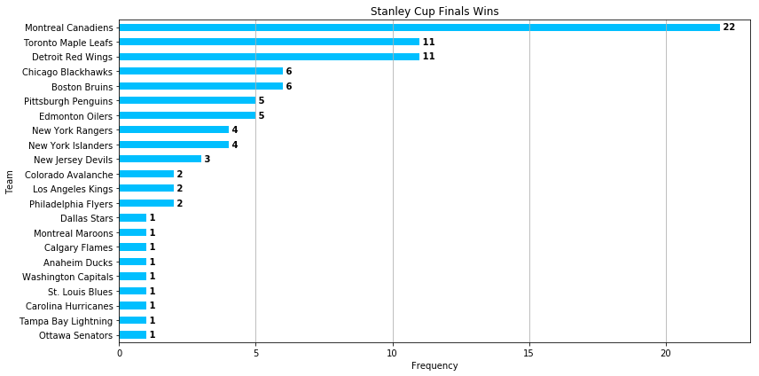

```python
plt.figure(num=1,figsize=(12,6))
team_wins = data.team_win.value_counts(ascending=True).plot.barh(color='deepskyblue')
team_wins.set_xlabel('Frequency')
team_wins.set_ylabel('Team')
team_wins.set_title('Stanley Cup Finals Wins')
team_wins.grid(True,which='major',axis='x')
for i,v in enumerate(data.team_win.value_counts(ascending=True)):
    team_wins.text(v,i," "+str(v), color='black',va='center',fontweight='bold')
plt.tight_layout()
plt.show()
```

### Most Stanley Cup Finals Wins by Coach

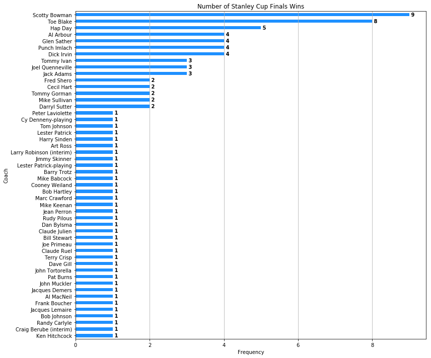

```python
plt.figure(num=2,figsize=(12,10))
coach_wins = data.coach_win.value_counts(ascending=True).plot.barh(color='dodgerblue')
coach_wins.set_xlabel('Frequency')
coach_wins.set_ylabel('Coach')
coach_wins.set_title('Number of Stanley Cup Finals Wins')
coach_wins.grid(True,which='major',axis='x')
for i,v in enumerate(data.coach_win.value_counts(ascending=True)):
    coach_wins.text(v,i," "+str(v), color='black',va='center',fontweight='bold')
plt.tight_layout()
plt.show()
```

### Most Stanley Cup Finals Loses by Team

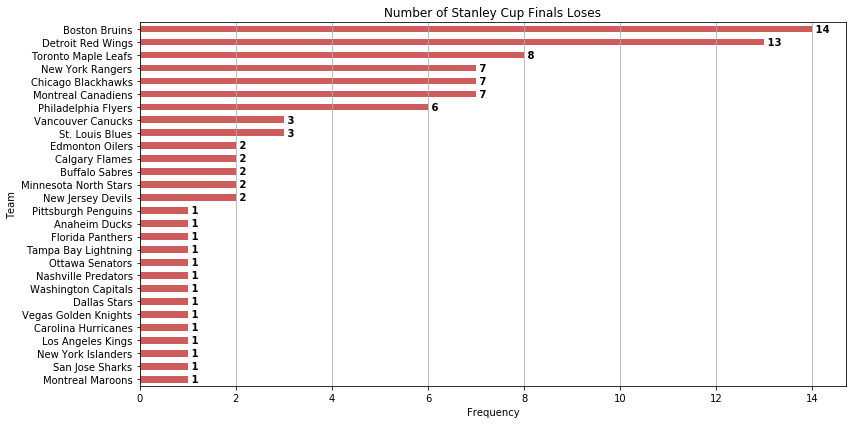

```python
plt.figure(num=3, figsize=(12,6))
team_loses = data.team_lose.value_counts(ascending=True).plot.barh(color='indianred')
team_loses.set_xlabel('Frequency')
team_loses.set_ylabel('Team')
team_loses.set_title('Number of Stanley Cup Finals Loses')
team_loses.grid(True,which='major',axis='x')
for i,v in enumerate(data.team_lose.value_counts(ascending=True)):
    team_loses.text(v,i," "+str(v), color='black',va='center',fontweight='bold')
plt.tight_layout()
plt.show()
```

### Most Stanley Cup Finals Loses by Coach

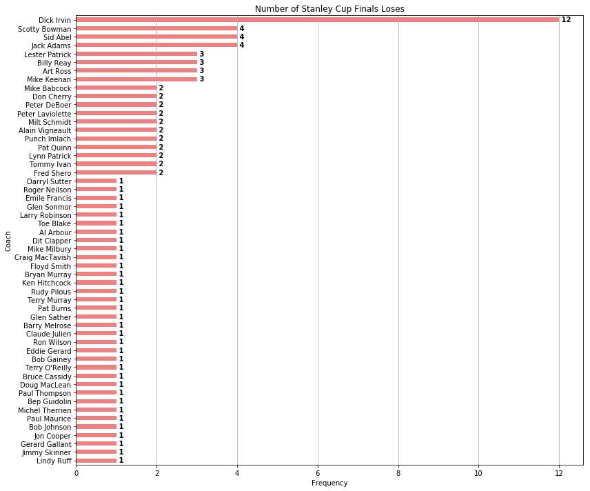

```python
plt.figure(num=4,figsize=(12,10))
coach_loses = data.coach_lose.value_counts(ascending=True).plot.barh(color='lightcoral')
coach_loses.set_xlabel('Frequency')
coach_loses.set_ylabel('Coach')
coach_loses.set_title('Number of Stanley Cup Finals Loses')
coach_loses.grid(True,which='major',axis='x')
for i,v in enumerate(data.coach_lose.value_counts(ascending=True)):
    coach_loses.text(v,i," "+str(v), color='black',va='center',fontweight='bold')
plt.tight_layout()
plt.show()
```

### Most Finals Appearances by Team

To calculate the total number of appearances by a team (win+lose) we must first create dictionaries of the win counts and lose counts seperatly, then combine them into a totals dictionary before we can plot.

```python
#create dictionaries of team appearances in cup final (win + lose)
win_dic = Counter(data['team_win'])
lose_dic = Counter(data['team_lose'])
Total_dic = win_dic + lose_dic
#Total_dic #uncomment to view dictionary
```

```python
#create df from above dictionary
total_cup_app = pd.DataFrame.from_dict(Total_dic, orient='index',columns=['Number of Cup Appearances'])
total_cup_app = total_cup_app.sort_values('Number of Cup Appearances',ascending=False)
total_cup_app.index.names = ['Team']
#total_cup_app #uncomment to view new df
```

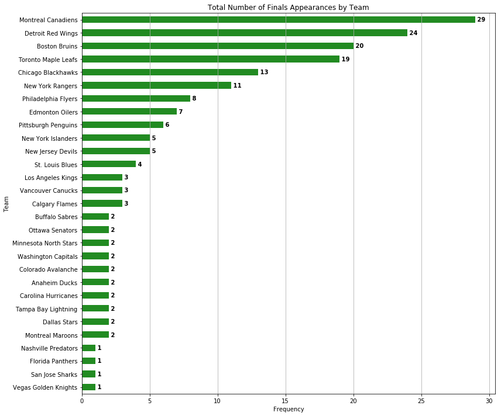

```python
plt.figure(num=5,figsize=(12,10))
total_team_appearances = total_cup_app['Number of Cup Appearances'].sort_values(ascending=True).plot.barh(color='forestgreen')
total_team_appearances.set_xlabel('Frequency')
total_team_appearances.set_title('Total Number of Finals Appearances by Team')
total_team_appearances.grid(True,which='major',axis='x')
for i,v in enumerate(total_cup_app['Number of Cup Appearances'].sort_values(ascending=True)):
    total_team_appearances.text(v,i," "+str(v), color='black',va='center',fontweight='bold')
plt.tight_layout()
```

### Most Finals Appearances by Coach

just like for teams above, we must create a dictionary containing counts from both win and lose columns.

```python
#create dic like team but for coaches
wc_dic = Counter(data['coach_win'])
lc_dic = Counter(data['coach_lose'])
coach_total_dic = wc_dic + lc_dic
#coach_total_dic #uncomment to view dictionary
```

```python
#create df from above dictionary
total_coach_app = pd.DataFrame.from_dict(coach_total_dic, orient='index',columns=['Number of Cup Appearances'])
total_coach_app = total_coach_app.sort_values('Number of Cup Appearances',ascending=False)
total_coach_app.index.names = ['Coach']
#total_coach_app #uncomment to view new df
```

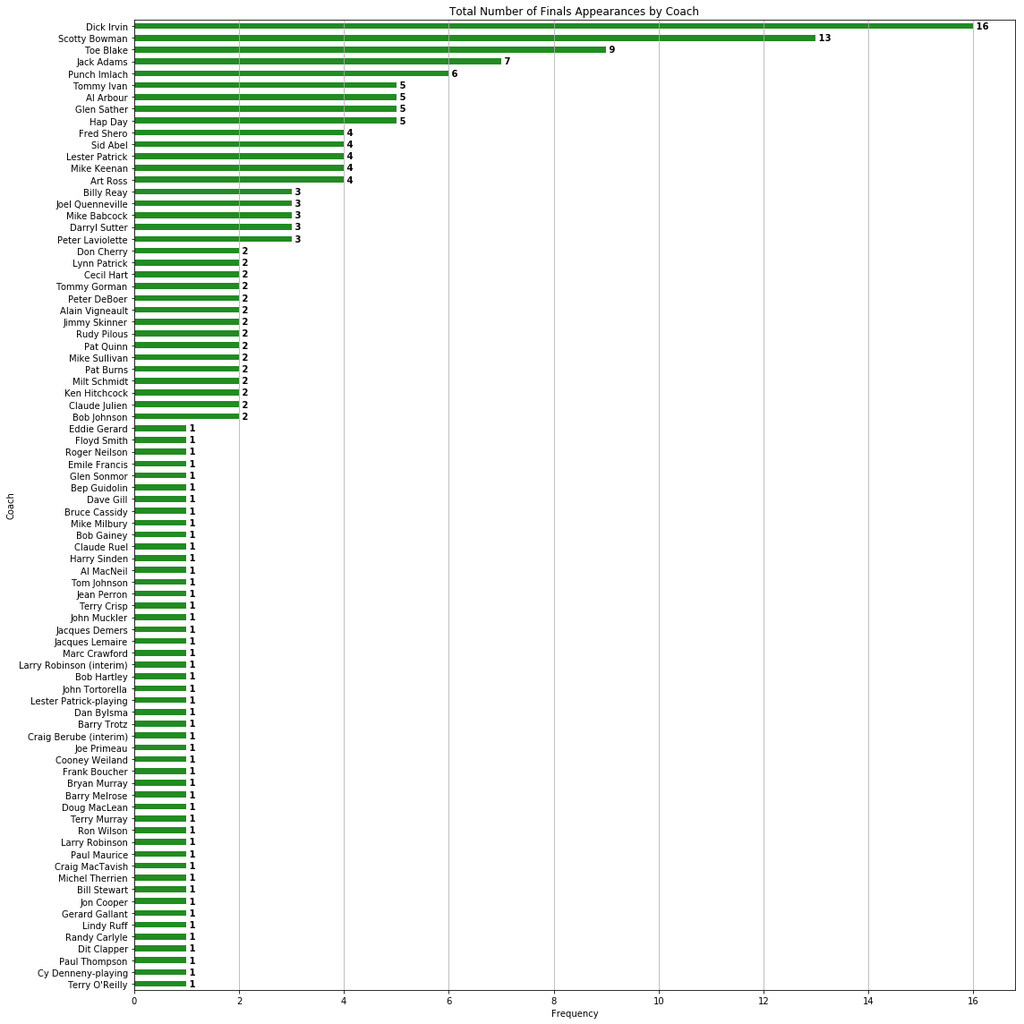

```python
plt.figure(num=6,figsize=(16,16))
total_coach_appearances = total_coach_app['Number of Cup Appearances'].sort_values(ascending=True).plot.barh(color='forestgreen')
total_coach_appearances.set_xlabel('Frequency')
total_coach_appearances.set_title('Total Number of Finals Appearances by Coach')
total_coach_appearances.grid(True,which='major',axis='x')
for i,v in enumerate(total_coach_app['Number of Cup Appearances'].sort_values(ascending=True)):
    total_coach_appearances.text(v,i," "+str(v), color='black',va='center',fontweight='bold')
plt.tight_layout()
```

### Game Winning Goal Distibution by Period

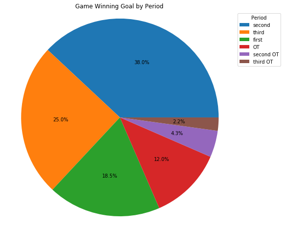

```python
plt.figure(num=7,figsize=(8,8))
labels = ['second','third','first','OT','second OT','third OT']
goal_dist = data.period.value_counts().plot.pie(labels=None,autopct='%1.1f%%')
goal_dist.axis('equal')
goal_dist.legend(labels,title='Period',loc='upper right',bbox_to_anchor=(0.75, 0, 0.5, 1))
goal_dist.set_ylabel(' ')
goal_dist.set_title('Game Winning Goal by Period')
```

### Number of Game Winning Goals by Skater

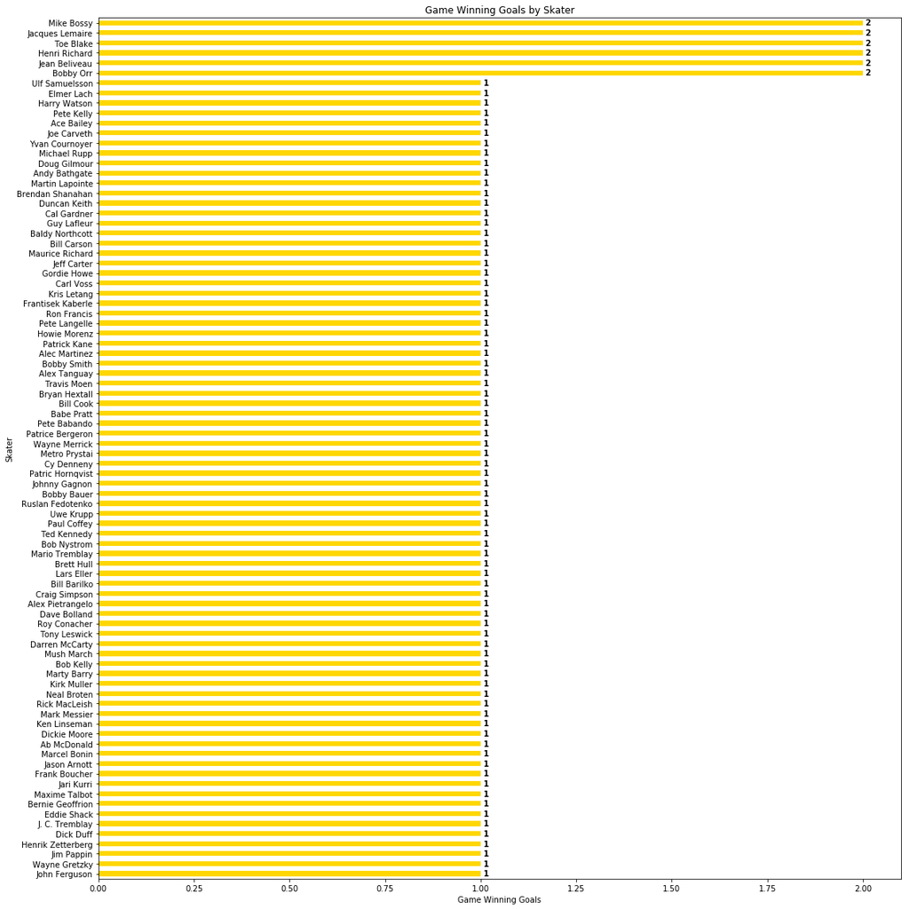

```python
plt.figure(num=8,figsize=(16,16))
goal_scorer = data.win_gs.value_counts(ascending=True).plot.barh(color="gold")
goal_scorer.set_ylabel('Skater')
goal_scorer.set_xlabel('Game Winning Goals')
goal_scorer.set_title('Game Winning Goals by Skater')
for i,v in enumerate(data.win_gs.value_counts(ascending=True)):
    goal_scorer.text(v,i," "+str(v), color='black',va='center',fontweight='bold')
plt.tight_layout()
```

### Categorizing Time of Goal

In hockey, it is said some of most most crucial goals come in either the first or last five minutes of the period, does this hold true for Cup winning goals? To check this a new column must be created -- gt_cat

```python
#convert to time object and categorize time of goal
data['goal_time'] = pd.to_datetime(data['goal_time'],format='%M:%S').dt.time
temp = pd.DataFrame(data['goal_time'],columns=['goal_time'])

temp[['goal_hour_DROP','goal_min','goal_sec']] = temp['goal_time'].astype(str).str.split(':', expand=True).astype(int)

temp = temp.drop('goal_hour_DROP',axis=1)
temp['gt_in_s'] = (temp['goal_min']*60) + temp['goal_sec']
temp['gt_cat'] = np.where(temp['gt_in_s'] <= 300, 'First 5',np.where(temp['gt_in_s'] >= 900, 'Final 5', 'Middle 10'))
data['gt_cat'] = temp['gt_cat']
data[['goal_time','gt_cat']].head()
```

| Year | goal_time | gt_cat |
| --- | --- | --- |
| 1927 | 00:07:30 | Middle 10 |
| 1928 | 00:03:35 | First 5 |
| 1929 | 00:18:02 | Final 5 |
| 1930 | 00:01:00 | First 5 |
| 1931 | 00:09:59 | Middle 10 |

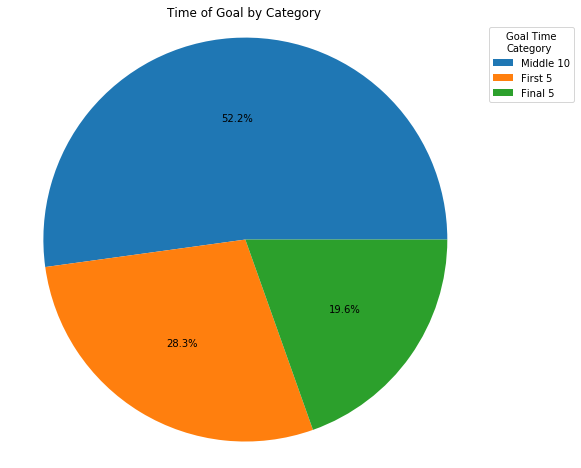

```python
plt.figure(num=8,figsize=(8,8))
cat_labels = ['Middle 10','First 5','Final 5']
gt_cat = data.gt_cat.value_counts().plot.pie(labels=None,autopct='%1.1f%%')
gt_cat.axis('equal')
gt_cat.set_ylabel(' ')
gt_cat.set_title('Time of Goal by Category')
gt_cat.legend(cat_labels,title='Goal Time\nCategory',loc='upper right',bbox_to_anchor=(0.75, 0, 0.5, 1))
```

### Percentage of Cups won in Overtime

The NHL has a long season, 82 regular season games, plus playoffs. For those sixteen teams who make playoffs, they face four best-of-seven rounds to the ultimate prize in hockey, The Stanley Cup. So of those teams, how many had to go through overtime for that 16th and final win?

```python
data['game_end'] = np.where(data['period'] == 'first','Regulation',np.where(data['period'] == 'second','Regulation',np.where(data['period'] == 'third','Regulation','Overtime')))
data[['period','game_end']].head()
```

| Year | period | game_end |
| --- | --- | --- |
| 1927 | second | Regulation |
| 1928 | third | Regulation |
| 1929 | third | Regulation |
| 1930 | second | Regulation |
| 1931 | second | Regulation |

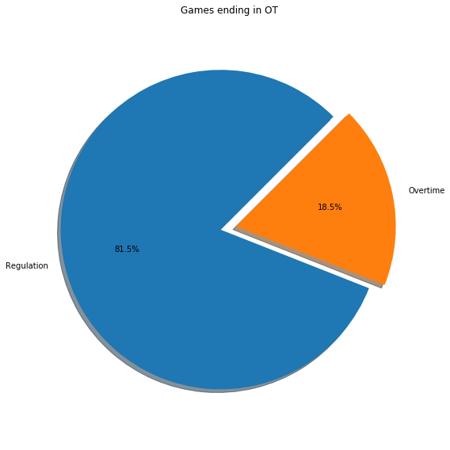

```python
plt.figure(num=9,figsize=(8,8))
explode = (0,0.1)
ot = data.game_end.value_counts().plot.pie(explode = explode, autopct='%1.1f%%',shadow=True,startangle=45)
ot.axis('equal')
ot.set_ylabel(' ')
ot.set_title('Games ending in OT')
plt.tight_layout()
```

## Step 9: Top 5 Visualizations

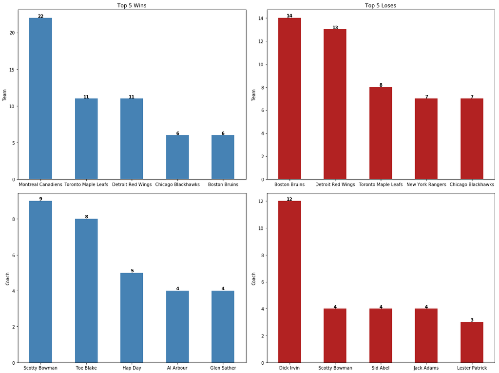

```python
t5_team_win = data.team_win.value_counts().head()
t5_team_lose = data.team_lose.value_counts().head()
t5_coach_win = data.coach_win.value_counts().head()
t5_coach_lose = data.coach_lose.value_counts().head()

plt.figure(num=10,figsize=(16,12))

plt.subplot(221)
t5_teamw = t5_team_win.plot.bar(color='steelblue')
plt.xticks(rotation=0)
for i,v in enumerate(t5_team_win):
    t5_teamw.text(i,v+0.05,str(v),color='black',ha='center',fontweight='bold')
t5_teamw.set_title('Top 5 Wins')
t5_teamw.set_ylabel('Team')
plt.tight_layout()

plt.subplot(223)
t5_coachw = t5_coach_win.plot.bar(color='steelblue')
plt.xticks(rotation=0)
for i,v in enumerate(t5_coach_win):
    t5_coachw.text(i,v+0.05,str(v),color='black',ha='center',fontweight='bold')
t5_coachw.set_ylabel('Coach')
plt.tight_layout()

plt.subplot(222)
t5_teaml = t5_team_lose.plot.bar(color='firebrick')
plt.xticks(rotation=0)
for i,v in enumerate(t5_team_lose):
    t5_teaml.text(i,v+0.05,str(v),color='black',ha='center',fontweight='bold')
t5_teaml.set_title('Top 5 Loses')
t5_teaml.set_ylabel('Team')
plt.tight_layout()

plt.subplot(224)
t5_coachl = t5_coach_lose.plot.bar(color='firebrick')
plt.xticks(rotation=0)
for i,v in enumerate(t5_coach_lose):
    t5_coachl.text(i,v+0.05,str(v),color='black',ha='center',fontweight='bold')
t5_coachl.set_ylabel('Coach')
plt.tight_layout()
```

## Next Steps

The analysis of this subject matter was limited due to the dataset, therefore a logical extension of this project would be to augment this dataset with all the box scores to see game by game results rather than only a total series summary. By having box scores from previous rounds as well it would be possible to investigate for any trends in characteristics of teams that make it to the cup finals.

As for extensions to our current dataset, filling the missing values for both the winning and losing team's conferences could be done by creating a dictionary of the current structure of the NHL, however as previously stated, there have been many rearragments of the NHL's structure since 1927 so this may raise some issues, particularily with franchises (teams) that have moved. For example, Winnipeg has had two seperate Jets franchises. From 1972-1996, the original Team played until the team moved to Arizona to become the Coyotes, where they still remain. A new Jets franchise came to Winnipeg in 2011, but from their inaugral season in 1999 up until 2011 they were actually the Atlanta Thrashers.

Another extension to the current data set could also be to add all current teams to the total appearances by team dictionary to show teams that are yet to make it to a Stanley Cup Final.

### References

List of Stanley Cup Champions - https://en.wikipedia.org/wiki/List_of_Stanley_Cup_champions#NHL_champions_(since_1927)